# Bikeshare - Cyclistic company study case

Obed Rios

3/22/2022

# 1 Introduction

Cyclistic [^1] launched an innovative bike-share program in 2016. The program has since expanded to a fleet of 5,824 bicycles that are geolocated and locked into 692 stations across Chicago. Any bike in the system can be unlocked from one station and returned to another at any time.

Cyclistic’s marketing strategy has been based on improving general awareness and appealing to a wide consumer base. The flexibility of its pricing options, including single-ride passes, full-day passes, and annual memberships, contributed to making these things possible.

In Cyclistic’s view, the customer is as follows:

- Customers who purchase single-ride or full-day passes are referred to as casual riders.
- Customers who purchase annual memberships are Cyclistic members.

Cyclistic’s financial analysts have concluded that annual members are much more profitable than casual riders. While Cyclistic’s pricing flexibility attracts more customers, its director of marketing believes that maximizing the number of annual members will be a key to future growth. Instead of creating an advertising campaign that aims to attract all new customers, the director of marketing believes that there is a very good chance of converting casual riders into members. According to her, casual riders are already familiar with Cyclistic and have chosen Cyclistic to meet their mobility needs.

## 1.1 Goals

### 1.1.1 General Goal

> Develop marketing strategies aimed at converting casual riders into members. To accomplish this, however, the marketing analyst team must first gain a deeper understanding of how annual members and casual riders differ, and why casual riders would choose to join. In addition, digital media might impact their marketing strategies. In order to identify trends, the marketing director and her team are interested in analyzing the Cyclistic historical data regarding bicycle trips.

### 1.1.2 Specifc Goal

> Analyze data in order to understand and present how annual members and casual riders use Cyclistic bicycles differently.

## 1.2 Methodology

In the present work, we used the CRISP-DM [^2] [^3] approach to get the first data insights about the customers behavior.

Initially we acquired the data from [Cyclistic 2021 Trip Data Repsository](https://divvy-tripdata.s3.amazonaws.com/index.html) provided by the data team., the we performed exploratory data analysis by cleaning missing data and verifying the variation convergence of the data. After clean and verify the data we explored the relationships using categorical values to explore the proportions of customers types and products usage.

# 2 Data Preparation

Preparation of data (Data-Prep) is an essential step before modeling and making conclusions about data. According to some, this is the most difficult and time-consuming stage because 80% of the project is dedicated to data preparation and 20% to the modeling process [^4]. As part of data preparation, there are various stages such as data acquisition, collection, data exploration, or exploratory data analysis which involves data cleansing and identifying errors, as well as missing imputations. Preparation of data is often the key to solving a problem. In many situations, it will make the difference between success and failure, between usable insights and unclear murk, and between useful forecasts and useless guesses.

In this section, first we integrate the data from a given repository, then we perform an exploratory data analysis. First we cleaned the data and then we explore the structure and relationship between the variables.

## 2.1 Data Integration

Initially, we used the following script to integrate data from several files:

```r
# Integrate Original Data
fnames <- paste('data', dir('data'), sep = '/')
bikeshare_2021 <- do.call(rbind, lapply(fnames, read.csv))
write.csv(bikeshare_2021, "bikeshare2021_data.csv", row.names = F)
```

The consolidated data is then generated into an integrated *Comma-Separated Values (CSV)* file. We performed exploratory data analysis (EDA) by using the consolidated file.

## 2.2 Exploratory Data Analysis (EDA)

In any type of research analysis, exploratory data analysis is a necessary step. An exploratory analysis is conducted in order to analyze the data for distribution, outliers, and anomalies in order to determine which hypothesis should be tested in greater detail. It also provides tools for developing hypotheses by visualizing and understanding the data, usually through graphical displays [^5].

Exploratory Data analysis is a fundamental early step after data collection and preprocessing. In the words of Howard Seltman (Carnegie Mellon University), “loosely speaking, exploratory data analysis refers to any method of looking at data that does not include a formal statistical model and inference.[^6]”

### 2.2.1 Initial examination of data structure

First we loaded the file using the following script:

```r
bikeshare2021 <- read_csv('bikeshare2021_data.csv')
```

Next, we used the following script to verify the original data structure based on the acquired data:

```r
glimpse(bikeshare2021)
```

```
## Rows: 5,595,063
## Columns: 13
## $ ride_id            <chr> "E19E6F1B8D4C42ED", "DC88F20C2C55F27F", "EC45C94683~
## $ rideable_type      <chr> "electric_bike", "electric_bike", "electric_bike", ~
## $ started_at         <dttm> 2021-01-23 16:14:19, 2021-01-27 18:43:08, 2021-01-~
## $ ended_at           <dttm> 2021-01-23 16:24:44, 2021-01-27 18:47:12, 2021-01-~
## $ start_station_name <chr> "California Ave & Cortez St", "California Ave & Cor~
## $ start_station_id   <chr> "17660", "17660", "17660", "17660", "17660", "17660~
## $ end_station_name   <chr> NA, NA, NA, NA, NA, NA, NA, NA, NA, "Wood St & Augu~
## $ end_station_id     <chr> NA, NA, NA, NA, NA, NA, NA, NA, NA, "657", "13258",~
## $ start_lat          <dbl> 41.90034, 41.90033, 41.90031, 41.90040, 41.90033, 4~
## $ start_lng          <dbl> -87.69674, -87.69671, -87.69664, -87.69666, -87.696~
## $ end_lat            <dbl> 41.89000, 41.90000, 41.90000, 41.92000, 41.90000, 4~
## $ end_lng            <dbl> -87.72000, -87.69000, -87.70000, -87.69000, -87.700~
## $ member_casual      <chr> "member", "member", "member", "member", "casual", "~
```

We know that there are dates and global position coordinates. First we wanted to add transformed data such, How long does a customer use service? and What is the distance from start point to end point?. To provide this information we used the following script to compute the distance from the starting point (where the service begins) to the end point (when the service ends):

```r
# Resource:
# https://www.movable-type.co.uk/scripts/latlong.html
dist.latlng_to_mts <- function(start.lat, start.lng, end.lat, end.lng){
  R <- 6371e3
  phi1 <- start.lat*pi/180
  phi2 <- end.lat*pi/180
  delta_phi <- (end.lat - start.lat)*pi/180
  delta_lam <- (end.lng - start.lng)*pi/180
  a <- sin(delta_phi/2)^2 + cos(phi1)*cos(phi2)*sin(delta_lam/2)^2
  c <- 2*atan2(sqrt(a), sqrt(1-a))
  d <- R*c # In meters
  d
}
```

Now we add the information by mutating the `bikeshare2021` dataset using:

```r
# Mutate quantify data
bikeshare2021 <- bikeshare2021 %>% mutate(
      use.length_in_mins = as.numeric(ended_at - started_at)/60,
      p2p.distance_in_kms = dist.latlng_to_mts(start_lat, start_lng,
                                               end_lat, end_lng)/1000) %>%
      select(-c(ride_id))

bikeshare2021 <- bikeshare2021 %>% mutate(week = week(started_at),
                                          month = month(started_at),
                                          month_name = month.name[month(started_at)])
bikeshare2021$rideable_type <- factor(bikeshare2021$rideable_type)
bikeshare2021$member_casual <- factor(bikeshare2021$member_casual)
```

We have added the following variables, as you may have noticed

- `use.length_in_mins` which represent the duration of the service.
- `p2p.distance_in_kms` which represents the distance from service starting point to service ending point.

### 2.2.2 Initial Data cleaning

In addition, the initial examination of the data structure revealed the existence of missing values. Because of the lack of end latitudes and end longitudes, there are missing point-to-point distance values. Furthermore, we discovered that the duration was either zero or negative. The records may be the result of a faulty recording. The script below was used to remove those records.

```r
# Remove rows with wrong Point-to-Point distance in Kms (End Lat & Long Missing)
bikeshare2021 <- bikeshare2021[!is.na(bikeshare2021$p2p.distance_in_kms),]

# Remove rows with Use service with 0 Minutes (Probably fault)
bikeshare2021 <- bikeshare2021[!(bikeshare2021$use.length_in_mins == 0),]

# Remove rows with wrong start Lat and Long (Wrong records)
bikeshare2021 <- bikeshare2021[!(bikeshare2021$use.length_in_mins < 0),]
```

The *station_id* has now been verified in accordance with the global position coordinates as shown below:

```r
station_id.pos <- bikeshare2021 %>% select(start_station_id, start_lat, start_lng, start_station_name, end_station_id, end_lat, end_lng, end_station_name, use.length_in_mins, p2p.distance_in_kms )
#
n_rows <- 0
while(n_rows < 5) {
  station_id.sample <- sample_n(station_id.pos,100000) %>%
    filter(start_station_id == '13022') %>%
    filter(end_station_id == '13001')
  n_rows <- nrow(station_id.sample)
}
#
station_id.sample
```

```
## # A tibble: 13 x 10
##    start_station_id start_lat start_lng start_station_na~ end_station_id end_lat
##    <chr>                <dbl>     <dbl> <chr>             <chr>            <dbl>
##  1 13022                 41.9     -87.6 Streeter Dr & Gr~ 13001             41.9
##  2 13022                 41.9     -87.6 Streeter Dr & Gr~ 13001             41.9
##  3 13022                 41.9     -87.6 Streeter Dr & Gr~ 13001             41.9
##  4 13022                 41.9     -87.6 Streeter Dr & Gr~ 13001             41.9
##  5 13022                 41.9     -87.6 Streeter Dr & Gr~ 13001             41.9
##  6 13022                 41.9     -87.6 Streeter Dr & Gr~ 13001             41.9
##  7 13022                 41.9     -87.6 Streeter Dr & Gr~ 13001             41.9
##  8 13022                 41.9     -87.6 Streeter Dr & Gr~ 13001             41.9
##  9 13022                 41.9     -87.6 Streeter Dr & Gr~ 13001             41.9
## 10 13022                 41.9     -87.6 Streeter Dr & Gr~ 13001             41.9
## 11 13022                 41.9     -87.6 Streeter Dr & Gr~ 13001             41.9
## 12 13022                 41.9     -87.6 Streeter Dr & Gr~ 13001             41.9
## 13 13022                 41.9     -87.6 Streeter Dr & Gr~ 13001             41.9
## # ... with 4 more variables: end_lng <dbl>, end_station_name <chr>,
## #   use.length_in_mins <dbl>, p2p.distance_in_kms <dbl>
```

```r
# Clean unused data frames
rm(station_id.pos)
rm(station_id.sample)
```

```r
# Create start stations register
start.stations <- bikeshare2021 %>% select(start_station_id,start_station_name, start_lat, start_lng) %>% drop_na()
start.stations <- start.stations[!duplicated(start.stations$start_station_id),]
names(start.stations) <- c("station_id",  "station_name", "lat", "lng")

# Create end stations register
end.stations <- bikeshare2021 %>% select(end_station_id, end_station_name, end_lat, end_lng) %>% drop_na()
end.stations <- end.stations[!duplicated(end.stations$end_station_id),]
names(end.stations) <- c("station_id",  "station_name", "lat", "lng")

# Create Stations register dictionary with outer-join between start and end stations
# stations.data <- merge(x=start.stations,y=end.stations,by="station_id", all=TRUE)
stations.book <- rbind(start.stations, end.stations)
stations.book <- stations.book[!duplicated(stations.book$station_id),]

# Get station stored in station book given lat and lng
get_station_id_name_by <- function(qlat, qlng){
  stations.book[stations.book$lat == qlat && stations.book$lng == qlng,] #[1,]
}


# Clean temporal data
rm(start.stations, end.stations)
```

and,

```r
 cbind(sample_n(bikeshare2021[is.na(bikeshare2021$end_station_id),] %>%
            select(end_lat, end_lng), 10),
 sample_n(bikeshare2021, 10) %>% select(end_lat, end_lng))
```

```
##    end_lat end_lng  end_lat   end_lng
## 1    41.93  -87.69 41.89399 -87.62932
## 2    41.92  -87.72 41.91000 -87.70000
## 3    41.70  -87.65 41.80256 -87.59037
## 4    41.87  -87.63 41.94011 -87.64545
## 5    41.91  -87.63 41.86897 -87.65914
## 6    41.96  -87.65 41.87764 -87.64962
## 7    41.79  -87.60 41.94947 -87.64645
## 8    41.89  -87.63 41.93627 -87.65266
## 9    41.94  -87.65 41.89897 -87.62991
## 10   41.90  -87.67 41.89185 -87.62058
```

Upon observing that missing values are due to an error in recording coordinate positions, we proceed to remove those rows using the following script.

```r
bikeshare2021 <- bikeshare2021[!is.na(bikeshare2021$end_station_id),]
```

Generally, the Chicago stations are distributed as follows:

```r
library(sf)
library(mapview)
library(maps)
library(rgdal)
library(sp)
library(leaflet)


# Web Resources
# https://rstudio.github.io/leaflet/markers.html
#
# chicago.map <- map('county','illinois')
# leaflet(chicago.map) %>% addTiles() %>%
#  addPolygons(stroke = TRUE, smoothFactor = 0.3, fillOpacity = 0.5)
names(stations.book)[c(3,4)] <- c("Latitude", "Longitude")
leaflet(stations.book) %>% addTiles() %>%
       addCircleMarkers(color = "Blue", radius = 1)
```

[interactive chart not shown]

### 2.2.3 Data Exploration

Currently, there are over 4 million records in the dataset. A phenomenon known as convergence can be used to obtain a representative sample. An instance value is selected at randomly from a population, one at a time, to take a sample. We start with a sample size of 0. Different sizes of random samples drawn from the same population will have different variability measures. As a larger and larger random sample is taken, the degree of variability between the smaller and larger samples tends to decrease. With the increase in sample size, the amount of fluctuation between successive samples decreases, and the number of measurements of variability converges toward a specific value.

Due to this convergence property, we can determine the level of confidence in a variable’s variability. There is a corresponding decrease in the amount of variability difference for each additional instance as the sample size increases. At some point, we can be certain with an arbitrary degree of certainty that more instances of data will not alter the variability by more than a particular amount [^7].

In this section we started to analyze the convergence variablity for the following variables: `member_casual`, `ridable_type`, `p2p_distance_in_kms`, `use.length_in_mins`. The following scripts were used to verify mentioned variables.

```r
library(vcd)
library(vcdExtra)

## Five summary and Standard Deviation Character Representation
summary.string <- function(numeric.var){
  nas.count <- sum(is.na(numeric.var))
  v.names <- c("min:", "p25:", "median:", "mean:", "p75:", "max:", "stdev:")
  #
  if(nas.count > 0) {
    v.names <- c("min:", "p25:", "median:", "mean:", "p75:", "max:", "na's:", "stdev:")
  }
  #
  results <- paste(v.names,
                   round(c(summary(numeric.var), stdev = sd(numeric.var, na.rm = TRUE)), digits = 2))
  paste(results, collapse = ",  ")
}

## Helper Method for Histogram and Boxplot Plot
hist.boxplot <- function(numeric.var,
                         main.hist = "",
                         xlab.hist = "",
                         main.boxplot = "",
                         xlab.boxplot = summary.string(numeric.var)){
  nf <- layout(mat = matrix(c(1,2),2,1, byrow = TRUE),  height = c(2,3))
  par(mar=c(5.1, 4.1, 1.1, 2.1))
  boxplot(numeric.var, horizontal = TRUE,  outline = TRUE, main = main.boxplot,
          ylim=c(min(numeric.var, na.rm = TRUE), max(numeric.var, na.rm = TRUE)),
          xlab = xlab.boxplot, frame.plot = TRUE, axes = TRUE, col = 'orange', pch = 20)
  #
  par(new  = TRUE)
  stripchart(numeric.var, pch = 15, col = 'darkblue', frame.plot = FALSE, axes = F,
             ylim = c(10, 0))
  #
  hist(numeric.var, xlim=c(min(numeric.var, na.rm = TRUE), max(numeric.var, na.rm = TRUE)),
       main = main.hist, xlab = xlab.hist, col = 'black', density = 20)
  par(mfrow = c(1,1))
}

## Helper Method for Rate of Variation Plot
plot.ratevariation <- function(numeric.var){
  cumulative <- cum.apply(numeric.var, sd, na.rm = TRUE)
  plot(cumulative, pch = 10, type = 'l', main = "Rate of Variation",
       xlab = "Variability Sample", ylab = "Confidence on Convergence",
       col = 'darkblue', first.panel = grid())
  abline(h = mean(cumulative, na.rm = TRUE), col = 'green')
  cumulative
}


## Accumulative Apply Function for numerical Values
cum.apply <- function(x, func, ...){
  n <- 1:length(x)
  unlist(lapply(n, function(index) func(x[1:index], ...)))
}


## Helper method for Histogram Boxplot plus Rate of Variation for Numerical Variables
hist.boxplot_withratevar <- function(numeric.var,
                                     main.hist = "",
                                     xlab.hist = "",
                                     main.boxplot = "",
                                     xlab.boxplot = summary.string(numeric.var)){
  #
  nf <- layout(mat = matrix(c(1,1,3,2,2,4), 2, 3, byrow = TRUE),  height = c(2,3,5))
  par(mar=c(5.1, 4.1, 2.1, 1.1))
  # Boxplot Chart
  boxplot(numeric.var, horizontal = TRUE,  outline = TRUE, main = main.boxplot,
          ylim=c(min(numeric.var, na.rm = TRUE), max(numeric.var, na.rm = TRUE)),
          xlab = xlab.boxplot, frame.plot = TRUE, axes = TRUE, col = 'orange', pch = 20)
  # StripChart added to Box plot
  par(new  = TRUE)
  stripchart(numeric.var, pch = 15, col = 'darkblue', frame.plot = FALSE, axes = F, ylim = c(10, 0))
  # Histogram Plot
  hist(numeric.var, xlim=c(min(numeric.var, na.rm = TRUE), max(numeric.var, na.rm = TRUE)),
       main = main.hist, xlab = xlab.hist, col = 'black', density = 20)
  ## Rate of Variation Plot
  x <- plot.ratevariation(numeric.var)
  plot(cum.apply(x, sd, na.rm = TRUE), type = 'l', col = "darkred", first.panel = grid(),
       xlab = "Index", ylab = "Variability of Convergence", main = "")
  par(mfrow = c(1,1))
}


# Easy Single Row Frame Create using character vectors as column names
data.frame_create <- function(names.colums_char, return.df = TRUE){
  x <- matrix(0, nrow = 1, ncol = length(names.colums_char))
  colnames(x) <- names.colums_char
  if(return.df) data.frame(x)
  else x
}

## Rate of Discovery for a categorical variables
rate.of_discovery <- function(categorical.var){
  if(is.numeric(categorical.var)) stop("Variable must be Factor or Character Type")
  #
  features <- tolower(as.character(unique(categorical.var)))
  counter <- 1:length(categorical.var)
  #
  results <- do.call(rbind, lapply(counter, function(index){
    def.row <- data.frame_create(features)
    prop.row <- prop.table(table(categorical.var[1:index]))
    names(prop.row) <- tolower(as.character(names(prop.row)))
    prop.row <- t(as.matrix(prop.row))
    #
    def.row[colnames(prop.row)]  <- c(prop.row)
    names(def.row) <- tolower(names(def.row))
    def.row
  }))
  #
  results <- data.frame(results)
  results
}

##
plot.categorical <- function(categorical.var){
  tabulated <- table(categorical.var)
  tabulated <- as.data.frame(tabulated)
  tabulated$Prop <- round(tabulated$Freq/sum(tabulated$Freq), digits = 3)
  names(tabulated) <- c("Levels", "Freq", "Prop")
  tabulated <- tabulated %>% arrange(Freq)
  #
  tabulated$Levels <- factor(tabulated$Levels)
  tabulated$Freq   <- factor(tabulated$Freq)
  tabulated$Prop   <- factor(tabulated$Prop)
  #
  p <- ggplot(tabulated, aes(x = Freq, y = Prop, fill = Levels)) +
    geom_bar(stat = "identity", position = "identity", colour = 'Black') + scale_fill_hue(l=20)
  #scale_fill_brewer(palette="Set3")
  p
}

##
plot.categorical_withrateofdiscovery <- function(categorical.var){
  #Helper Method
  stack.rateofdiscovery_df <- function(results){
    result <- lapply(names(results), function(name) {
      index <- length(name)
      result <- cbind.data.frame(results[name], name)
      colnames(result) <- c("value", "variable")
      result
    })
    #
    result <- lapply(result, function(x) {
      cbind.data.frame(index = 1:nrow(x), x)})
    result
  }
  #
  #
  results <- stack.rateofdiscovery_df(rate.of_discovery(categorical.var))
  p1 <- ggplot(data = do.call(rbind, results), aes(x=index, y=as.numeric(value))) +
    geom_line(aes(colour=variable)) + theme_bw()
  p2 <- plot.categorical(categorical.var) + theme_bw()
  #
  grid.newpage()
  pushViewport(viewport(layout = grid.layout(1, 2)))
  vplayout <- function(x, y) viewport(layout.pos.row = x, layout.pos.col = y)
  #
  print(p2, vp = vplayout(1,1))
  print(p1, vp = vplayout(1,2))
}
```

Figure 2.1, shows the variability convergence for the variable `use.length_in_min` which represents the time that customer use the service.

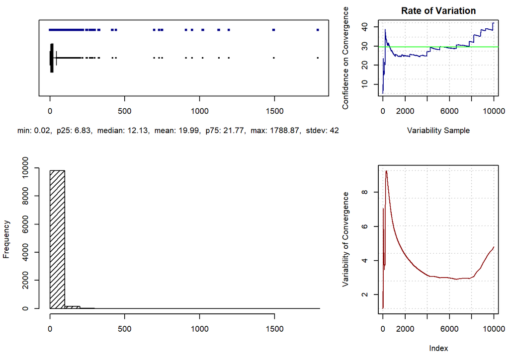

Figure 2.1: Variability convergence for Customer use in Minutes

Figure 2.2 shows the variability converge near $n = 6000$. Also we obtained a heavy tail distribution for the point to point distance variable.

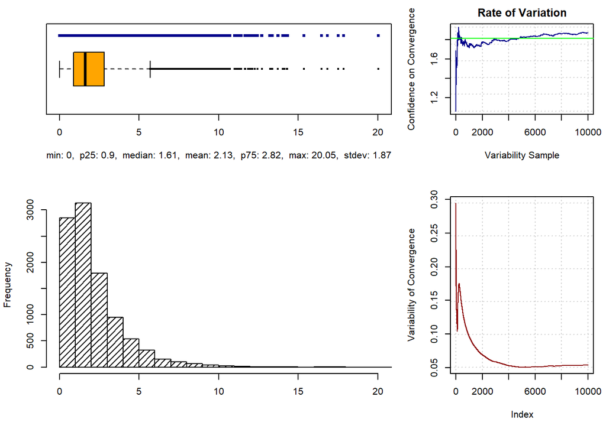

Figure 2.2: Variability convergence for point-to-point distance in Kms

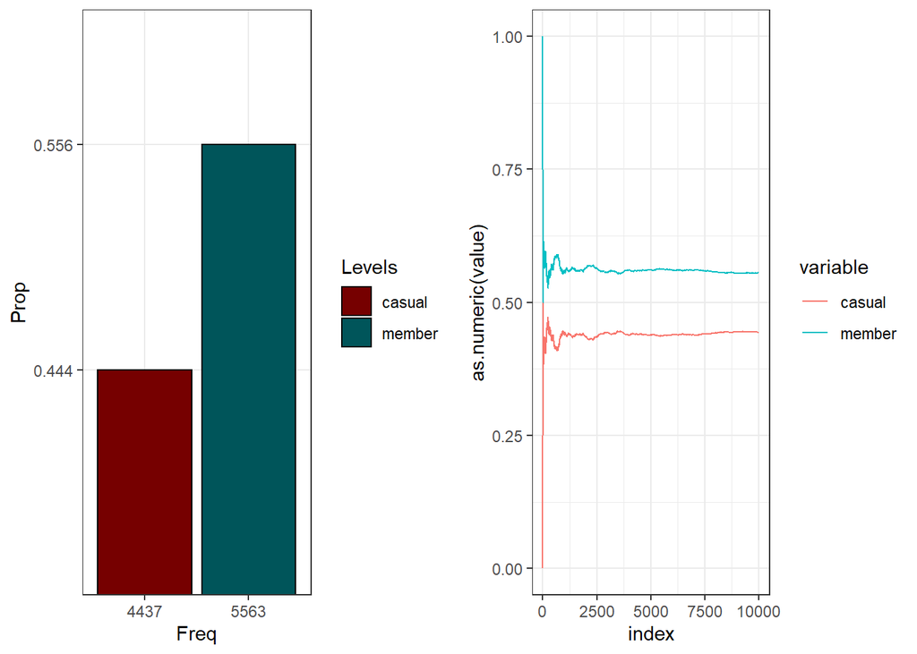

Figure 2.3: Variability convergence for the categorical variable `member_casual`

Figure 2.3 shows the distribution for the categorical variable `member_casual`. In fig. 2.3 we observe the proportion for the two categories `casual`and `member` customers which are similar. The variability convergence for this particular sample for two categories less than $n = 2000$.

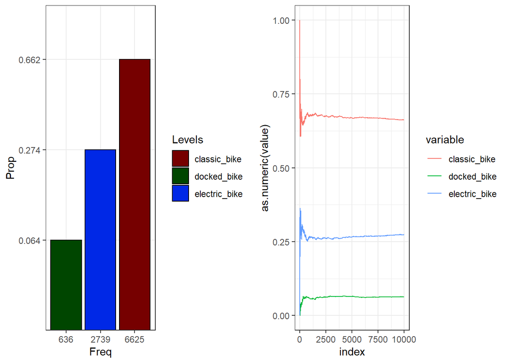

Figure 2.4: Variability convergence for categorical variable `rideable_type`

It can be seen from the fig. 2.4 that the variability convergence is quite similar with less than $n = 2000$. However, for the variable `rydable_type` we observe that the proportion of `docked_bike` is less than $7\%$, and we would only consider the categories `classic_bike` and `electric_bike` for the current analysis.

Now, the following table presents the five summary for the entire dataset for the variables `p2p,distance_in_kms`, `use.lenght_in_mins`,

```
##                                        min       p25   median       p75
## Point-to-Point distance in kms  0.00000000 0.9166675  1.64397  2.873774
## Customer use service in minutes 0.01666667 6.9500000 12.21667 22.016667
##                                         max
## Point-to-Point distance in kms     33.80028
## Customer use service in minutes 55944.15000
```

where we observe that, customer data gathered includes customers who pick up a bike at certain points and end service at a point that is approximately $33$ kilometers away from where they initially picked up the bike. This dataset also contains customers who have used the service for $40$ days. There is certainly a need to verify these extreme values with the financial department if they really exist and customers are willing to pay for that long a period.

In order to identify a pattern of customer behavior, the next step was to examine variable relationships. We constructed a two-way proportion table to verify the relationship between customers who are members and the kinds of services they use. The table is expressed as follows:

```r
kable(round(prop.table(xtabs(~ member_casual + rideable_type,
                              data = bikeshare2021))*100,2))
```

|  | classic_bike | docked_bike | electric_bike |
| --- | --- | --- | --- |
| casual | 25.98 | 6.43 | 12.16 |
| member | 40.78 | 0.00 | 14.65 |

whose graphical representation can be observed in fig. 2.5. Figure 2.5 depicts that casual customers are more likely to use docked and electric bikes, while members are more likely to use classic bikes.

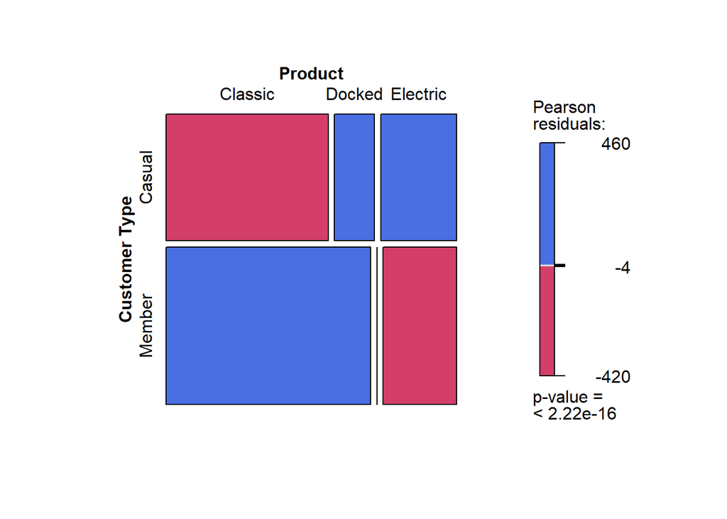

Figure 2.5: Moscaic plot to explore relationship between Product and Membership type

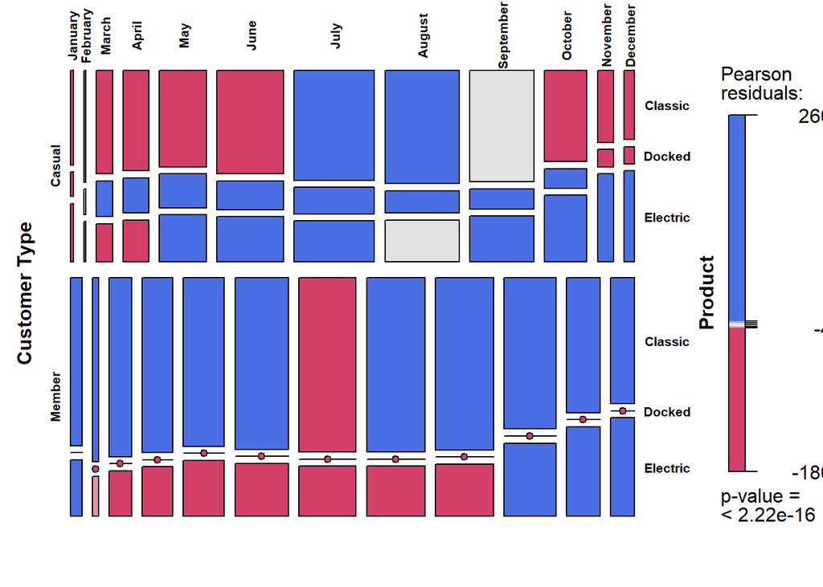

Figure 2.6: Moscaic plot to explore relationship between Product Membership type and moths

Our next step is to enhance the dataset in order to categorize the behavior by adding the following variables:

- Point-to-Point distance with the following categories:
  - Less than 1Km
  - Between 1Km and 5Km
  - More than 5 Km
- Customer use service length in Min with the following caterogies:
  - Less than 24 Hrs
  - More than 24 and less than a week
  - More than a week

The follwing snippet to add the variables is given by

```r
bikeshare2021 <- within(bikeshare2021, {
 p2pdistcat <- NA
 p2pdistcat[p2p.distance_in_kms <= 1] <- "Less than 1Km"
 p2pdistcat[p2p.distance_in_kms > 1 & p2p.distance_in_kms < 5] <- "Between 1km and 5km"
 p2pdistcat[p2p.distance_in_kms >= 5] <- "More than 5km"
})


bikeshare2021 <- within(bikeshare2021, {
 use.timemin_cat <- NA
 use.timemin_cat[use.length_in_mins <= 1440] <- "Less than 24Hrs"
 use.timemin_cat[use.length_in_mins > 1440 & use.length_in_mins < 10080] <- "Between 1 Day and 1 Week"
 use.timemin_cat[use.length_in_mins >= 10080] <- "More than a Week"
})
```

Now, first we may verify the proportions of customers using the service for a given time

```r
prop.table(table(bikeshare2021$use.timemin_cat))*100
```

```
##
## Between 1 Day and 1 Week          Less than 24Hrs         More than a Week
##              0.021026904             99.973742113              0.005230983
```

As we may observe, the proportion of customers users more than day is low, we may filter this data by performing

```r
bikeshare2021 <- bikeshare2021 %>% filter(use.timemin_cat != "Between 1 Day and 1 Week" & use.timemin_cat != 'More than a Week')
```

Now, we may verify the relationship categorical using the following mosaic plots

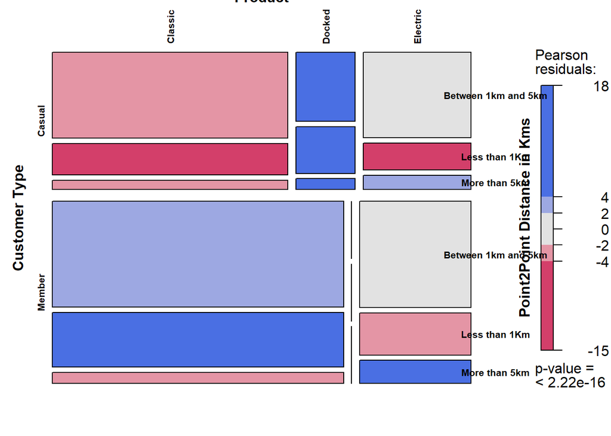

Figure 2.7: Moscaic plot to explore relationship between Product Membership type and Pick-Leave range distance

# 3 Conclusion